# Mapping tools

Package tests

Ben Anderson (b.anderson@soton.ac.uk, `@dataknut`)

Last run at: 2019-03-13 15:45:04

# 1 Why are we here?

To learn how to do mapping in R (markdown). Also uses data.table (Dowle et al. 2015) for data manipulation and ggplot (Wickham 2009).

Files we’re going to use:

- a .shp file defining the boundaries and data of the NZ [New Zealand Index of Multiple Deprivation (IMD)](https://www.fmhs.auckland.ac.nz/en/soph/about/our-departments/epidemiology-and-biostatistics/research/hgd/research-themes/imd.html) - see (Exeter et al. 2017)

# 2 Mapping packages

## 2.1 ggmap (Kahle and Wickham 2013)

Skipped due to google maps API requirement.

## 2.2 sf (Pebesma 2018)

See https://r-spatial.github.io/sf/ for documentation

Let’s draw a map of the Dunedin district. For those who don’t know this is *way* [bigger](https://en.wikipedia.org/wiki/Dunedin) than the urban area itself - it includes a lot of forests for example!

```r
library(sf)
myParams$dunners.shp <- sf::st_read(myParams$dunnersFile)
```

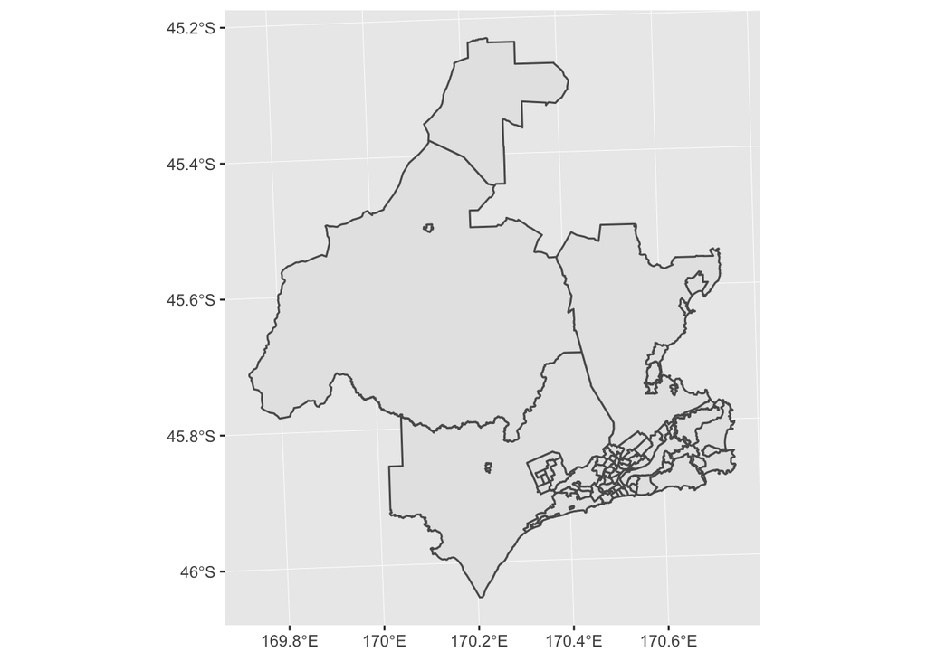

Figure 2.1: sf - basic map examples

```r
m <- ggplot2::ggplot() +
  geom_sf(data = myParams$dunners.shp)

m
```

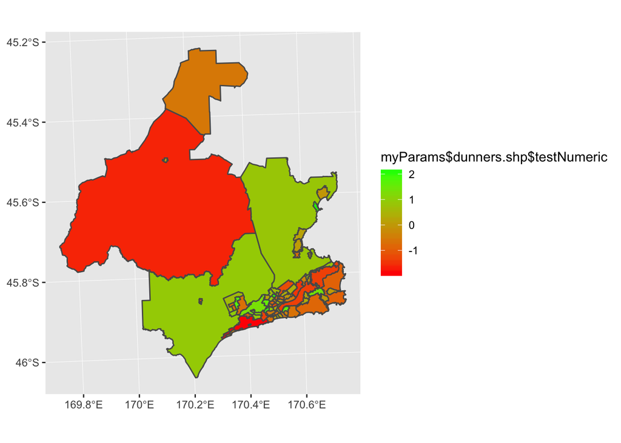

Figure 2.2: sf - basic map examples

```r
myParams$dunners.shp$testNumeric <- rnorm(n = nrow(myParams$dunners.shp)) # generate some numbers

m <- ggplot2::ggplot() +
  geom_sf(data = myParams$dunners.shp,
          aes(fill = myParams$dunners.shp$testNumeric)) + # aes works as you'd expect in ggplot
  scale_fill_continuous(low = "red", high = "green")

m
```

```
## Zoom: 10
```

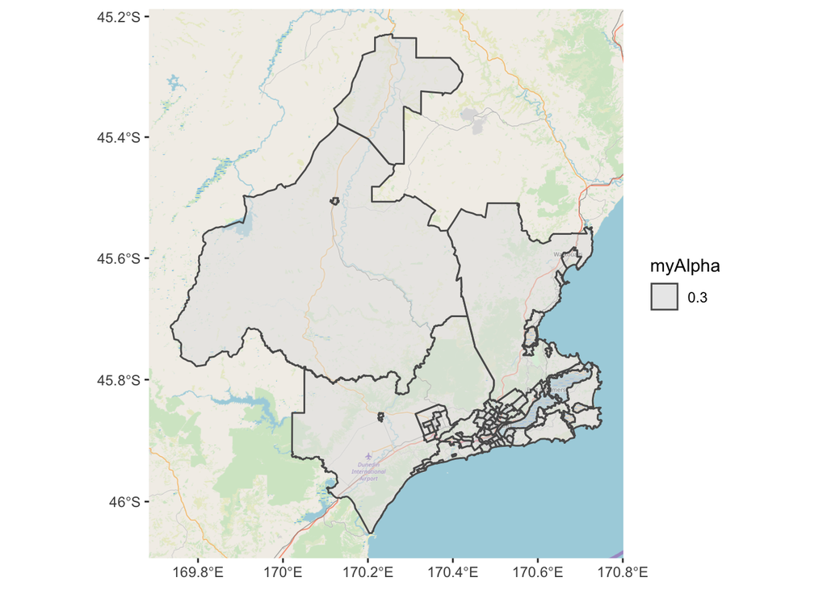

Figure 2.3: sf - map tile examples

```r
library(ggspatial)
myZoom = 10
myAlpha <- 0.3
# will fail if no internet
m <- ggplot2::ggplot() +
  annotation_map_tile(zoom = myZoom) + # do this first otherwise it masks the data layers
  geom_sf(data = myParams$dunners.shp, aes(alpha = myAlpha)) +
  scale_fill_continuous(low = "red", high = "green")

m
```

```
## Zoom: 10
```

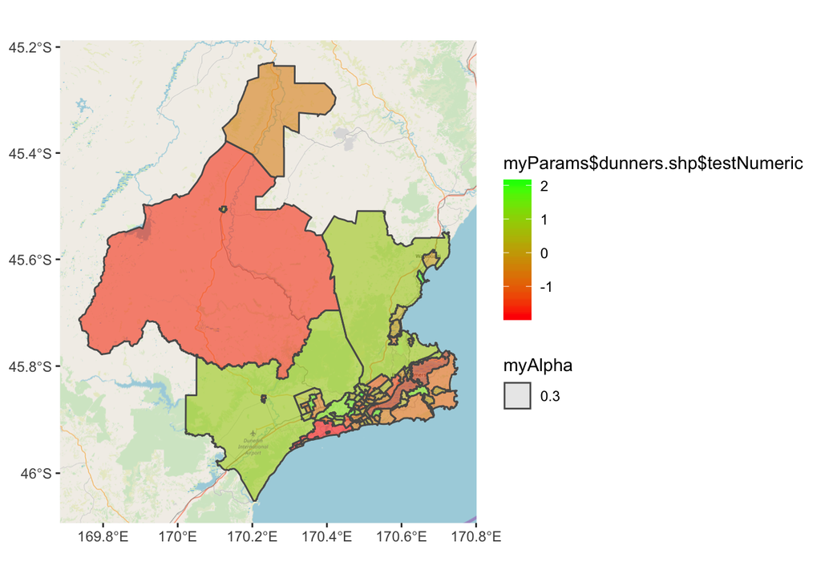

Figure 2.4: sf - map tile examples

```r
m <- ggplot2::ggplot() +
  annotation_map_tile(zoom = myZoom) + # do this first otherwise it masks the data layers
  geom_sf(data = myParams$dunners.shp, aes(fill = myParams$dunners.shp$testNumeric,
                                           alpha = myAlpha)) +
  scale_fill_continuous(low = "red", high = "green")

m
```

## 2.3 leaflet (Cheng, Karambelkar, and Xie 2018)

Figure 2.5 shows where R started :-)

```r
library(leaflet)

# will fail if no internet
# uses pipes (doesn't have to)

m <- leaflet() %>%
  addTiles() %>%  # Add default OpenStreetMap map tiles
  addMarkers(lng=174.768, lat=-36.852, popup="The birthplace of R")
m  # Print the map
```

[interactive chart not shown]

Figure 2.5: leaflet - basic plot showing the birthplace of R!

How do we do .shp files in leaflet?

## 2.4 mapview (Appelhans et al. 2018)

To do

# 3 About

## 3.1 Runtime

Analysis completed in: 13.71 seconds using knitr in [RStudio](http://www.rstudio.com) with R version 3.5.2 (2018-12-20) running on x86_64-apple-darwin15.6.0.

R packages used (data.table, ggplot2 plus others loaded where relevant):

- base R - for the basics (R Core Team 2016)
- ggmap - maps on ggplot (Kahle and Wickham 2013)
- ggplot2 - for slick graphics (Wickham 2009)
- ggspatial - to add tile features to ggplot-based maps (Dunnington 2018)
- knitr - to create this document (Xie 2016)
- leaflet - leaflet based maps (Cheng, Karambelkar, and Xie 2018)
- mapview - mapview maps (Appelhans et al. 2018)
- sf - maps on ggplot (Pebesma 2018)

# References

Appelhans, Tim, Florian Detsch, Christoph Reudenbach, and Stefan Woellauer. 2018. *Mapview: Interactive Viewing of Spatial Data in R*. https://CRAN.R-project.org/package=mapview.

Cheng, Joe, Bhaskar Karambelkar, and Yihui Xie. 2018. *Leaflet: Create Interactive Web Maps with the Javascript ’Leaflet’ Library*. https://CRAN.R-project.org/package=leaflet.

Dowle, M, A Srinivasan, T Short, S Lianoglou with contributions from R Saporta, and E Antonyan. 2015. *Data.table: Extension of Data.frame*. https://CRAN.R-project.org/package=data.table.

Dunnington, Dewey. 2018. *Ggspatial: Spatial Data Framework for Ggplot2*. https://CRAN.R-project.org/package=ggspatial.

Exeter, Daniel John, Jinfeng Zhao, Sue Crengle, Arier Lee, and Michael Browne. 2017. “The New Zealand Indices of Multiple Deprivation (IMD): A New Suite of Indicators for Social and Health Research in Aotearoa, New Zealand.” *PloS One* 12 (8): e0181260.

Kahle, David, and Hadley Wickham. 2013. “Ggmap: Spatial Visualization with Ggplot2.” *The R Journal* 5 (1): 144–61. http://journal.r-project.org/archive/2013-1/kahle-wickham.pdf.

Pebesma, Edzer. 2018. “Simple Features for R: Standardized Support for Spatial Vector Data.” *The R Journal*. https://journal.r-project.org/archive/2018/RJ-2018-009/index.html.

R Core Team. 2016. *R: A Language and Environment for Statistical Computing*. Vienna, Austria: R Foundation for Statistical Computing. https://www.R-project.org/.

Wickham, Hadley. 2009. *Ggplot2: Elegant Graphics for Data Analysis*. Springer-Verlag New York. http://ggplot2.org.

Xie, Yihui. 2016. *Knitr: A General-Purpose Package for Dynamic Report Generation in R*. https://CRAN.R-project.org/package=knitr.